# HW 2

Eve Wicksteed

22/09/2019

## Intro

Have a look at the gapminder data:

```r
DT::datatable(
gapminder)
```

|  | country | continent | year | lifeExp | pop | gdpPercap |
| --- | --- | --- | --- | --- | --- | --- |
| 1 | Afghanistan | Asia | 1952 | 28.801 | 8425333 | 779.4453145 |
| 2 | Afghanistan | Asia | 1957 | 30.332 | 9240934 | 820.8530296 |
| 3 | Afghanistan | Asia | 1962 | 31.997 | 10267083 | 853.10071 |
| 4 | Afghanistan | Asia | 1967 | 34.02 | 11537966 | 836.1971382 |
| 5 | Afghanistan | Asia | 1972 | 36.088 | 13079460 | 739.9811058 |
| 6 | Afghanistan | Asia | 1977 | 38.438 | 14880372 | 786.11336 |
| 7 | Afghanistan | Asia | 1982 | 39.854 | 12881816 | 978.0114388 |
| 8 | Afghanistan | Asia | 1987 | 40.822 | 13867957 | 852.3959448 |
| 9 | Afghanistan | Asia | 1992 | 41.674 | 16317921 | 649.3413952 |
| 10 | Afghanistan | Asia | 1997 | 41.763 | 22227415 | 635.341351 |

[output cut: 1694 more lines]

## Question 1.1

Use filter() to subset the gapminder data to three countries of your choice in the 1970’s.

```r
knitr::kable(
(eves_data <- gapminder %>%
  filter((country == "South Africa" | country == "Canada" | country == "United Kingdom") &
           (year >= 1970 & year <= 1979)))
)
```

| country | continent | year | lifeExp | pop | gdpPercap |
| --- | --- | --- | --- | --- | --- |
| Canada | Americas | 1972 | 72.880 | 22284500 | 18970.571 |
| Canada | Americas | 1977 | 74.210 | 23796400 | 22090.883 |
| South Africa | Africa | 1972 | 53.696 | 23935810 | 7765.963 |
| South Africa | Africa | 1977 | 55.527 | 27129932 | 8028.651 |
| United Kingdom | Europe | 1972 | 72.010 | 56079000 | 15895.116 |
| United Kingdom | Europe | 1977 | 72.760 | 56179000 | 17428.748 |

## Question 1.2

Use the pipe operator %>% to select “country” and “gdpPercap” from your filtered dataset in 1.1.

```r
knitr::kable(
eves_data %>%
  select(country, gdpPercap))
```

| country | gdpPercap |
| --- | --- |
| Canada | 18970.571 |
| Canada | 22090.883 |
| South Africa | 7765.963 |
| South Africa | 8028.651 |
| United Kingdom | 15895.116 |
| United Kingdom | 17428.748 |

## Question 1.3

Filter gapminder to all entries that have experienced a drop in life expectancy. Be sure to include a new variable that’s the increase in life expectancy in your tibble. Hint: you might find the lag() or diff() functions useful.

First attempt before class on Tuesday… see later answer.

```r
knitr::kable(
gapminder %>%
  mutate(change_lifeExp = lifeExp - first(lifeExp)) %>%
  filter(change_lifeExp <0)
)
```

| country | continent | year | lifeExp | pop | gdpPercap | change_lifeExp |
| --- | --- | --- | --- | --- | --- | --- |
| Rwanda | Africa | 1992 | 23.599 | 7290203 | 737.0686 | -5.202 |

After class on Tuesday (24 Sep):

```r
gapminder %>%
  arrange(year) %>%
  group_by(country) %>%
  mutate(gdpPercap_inc = gdpPercap - lag(gdpPercap)) %>%
  filter(gdpPercap_inc < 0)
```

```
## # A tibble: 332 x 7
## # Groups:   country [115]
##    country          continent  year lifeExp     pop gdpPercap gdpPercap_inc
##    <fct>            <fct>     <int>   <dbl>   <int>     <dbl>         <dbl>
##  1 Bangladesh       Asia       1957    39.3  5.14e7      662.         -22.6
##  2 Benin            Africa     1957    40.4  1.93e6      960.        -103.
##  3 Bolivia          Americas   1957    41.9  3.21e6     2128.        -550.
##  4 Haiti            Americas   1957    40.7  3.51e6     1727.        -113.
##  5 Malaysia         Asia       1957    52.1  7.74e6     1810.         -21.1
##  6 Morocco          Africa     1957    45.4  1.14e7     1642.         -46.2
##  7 Sao Tome and Pr… Africa     1957    48.9  6.13e4      861.         -18.8
##  8 Sri Lanka        Asia       1957    61.5  9.13e6     1073.         -11.0
##  9 Tanzania         Africa     1957    43.0  9.45e6      699.         -18.1
## 10 Tunisia          Africa     1957    47.1  3.95e6     1395.         -73.2
## # … with 322 more rows
```

## Question 1.4

Filter gapminder so that it shows the max GDP per capita experienced by each country. Hint: you might find the max() function useful here.

```r
DT::datatable(
gapminder %>%
  group_by(country) %>%
  filter(gdpPercap == max(gdpPercap)))
```

|  | country | continent | year | lifeExp | pop | gdpPercap |
| --- | --- | --- | --- | --- | --- | --- |
| 1 | Afghanistan | Asia | 1982 | 39.854 | 12881816 | 978.0114388 |
| 2 | Albania | Europe | 2007 | 76.423 | 3600523 | 5937.029526 |
| 3 | Algeria | Africa | 2007 | 72.301 | 33333216 | 6223.367465 |
| 4 | Angola | Africa | 1967 | 35.985 | 5247469 | 5522.776375 |
| 5 | Argentina | Americas | 2007 | 75.32 | 40301927 | 12779.37964 |
| 6 | Australia | Oceania | 2007 | 81.235 | 20434176 | 34435.36744 |
| 7 | Austria | Europe | 2007 | 79.829 | 8199783 | 36126.4927 |
| 8 | Bahrain | Asia | 2007 | 75.635 | 708573 | 29796.04834 |
| 9 | Bangladesh | Asia | 2007 | 64.062 | 150448339 | 1391.253792 |
| 10 | Belgium | Europe | 2007 | 79.441 | 10392226 | 33692.60508 |

[output cut: 132 more lines]

## Question 1.5

Produce a scatterplot of Canada’s life expectancy vs. GDP per capita using ggplot2, without defining a new variable. That is, after filtering the gapminder data set, pipe it directly into the ggplot() function. Ensure GDP per capita is on a log scale.

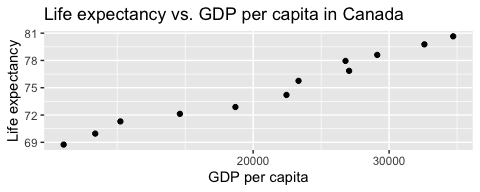

```r
gapminder %>%
  filter(country =="Canada") %>%
  ggplot(aes(gdpPercap, lifeExp)) +
    geom_point() +
    xlab("GDP per capita") +
    ylab("Life expectancy") +
    ggtitle("Life expectancy vs. GDP per capita in Canada")+
    scale_x_log10()
```

What are possible values (or range, whichever is appropriate) of each variable? What values are typical? What’s the spread? What’s the distribution? Etc., tailored to the variable at hand. Feel free to use summary stats, tables, figures.

### A look at life expectancy:

Summary stats:

The range of values are from 23.60 to 82.60.

```r
summary(gapminder$lifeExp)
```

```
##    Min. 1st Qu.  Median    Mean 3rd Qu.    Max.
##   23.60   48.20   60.71   59.47   70.85   82.60
```

Distribution of life expectancy

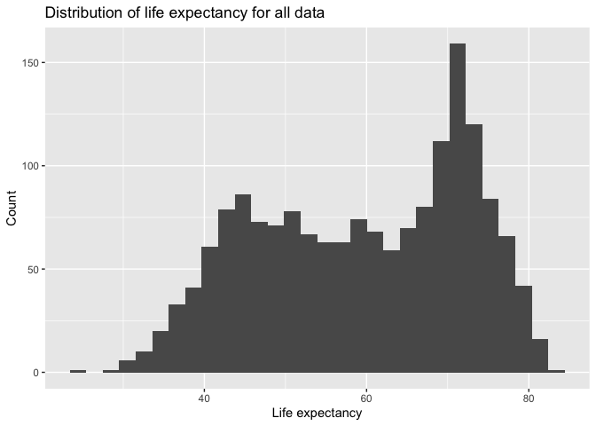

```r
ggplot(gapminder, aes(lifeExp)) +
  geom_histogram()+
  ylab("Count")+
  xlab("Life expectancy")+
  ggtitle("Distribution of life expectancy for all data")
```

### A look at continents:

These are possible values and the count of each:

```r
summary(gapminder$continent)
```

```
##   Africa Americas     Asia   Europe  Oceania
##      624      300      396      360       24
```

And the histogram for continents:

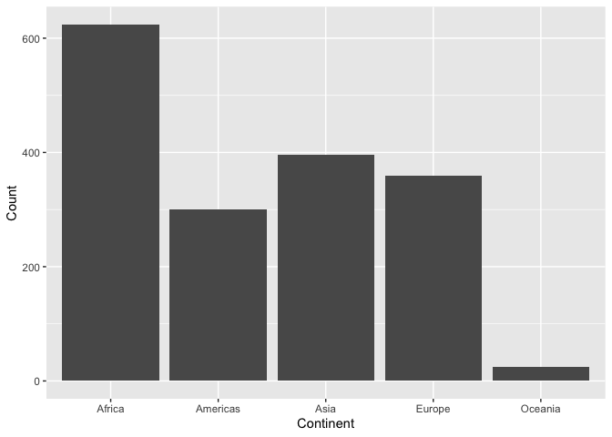

```r
ggplot(gapminder, aes(continent)) +
  geom_bar()+
  ylab("Count")+
  xlab("Continent")
```

Then we can also look at the distribution for life expectancy over the continents:

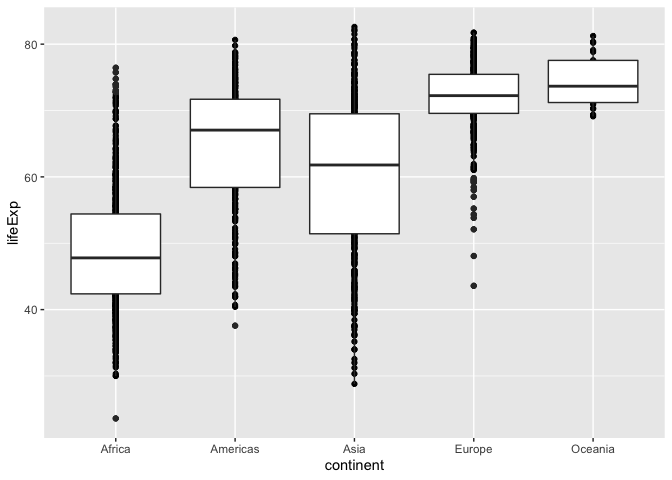

```r
ggplot(gapminder, aes(continent, lifeExp)) +
  geom_point() +
  geom_boxplot()
```

## Question 3

Make two plots that have some value to them. That is, plots that someone might actually consider making for an analysis. Just don’t make the same plots we made in class – feel free to use a data set from the datasets R package if you wish.

A scatterplot of two quantitative variables. One other plot besides a scatterplot. You don’t have to use all the data in every plot! It’s fine to filter down to one country or a small handful of countries.

Load in the air quality dataset from r datasets which shows New York air quality measurements

```r
library(datasets)

DT::datatable(airquality)
```

|  | Ozone | Solar.R | Wind | Temp | Month | Day |
| --- | --- | --- | --- | --- | --- | --- |
| 1 | 41 | 190 | 7.4 | 67 | 5 | 1 |
| 2 | 36 | 118 | 8 | 72 | 5 | 2 |
| 3 | 12 | 149 | 12.6 | 74 | 5 | 3 |
| 4 | 18 | 313 | 11.5 | 62 | 5 | 4 |
| 5 |  |  | 14.3 | 56 | 5 | 5 |
| 6 | 28 |  | 14.9 | 66 | 5 | 6 |
| 7 | 23 | 299 | 8.6 | 65 | 5 | 7 |
| 8 | 19 | 99 | 13.8 | 59 | 5 | 8 |
| 9 | 8 | 19 | 20.1 | 61 | 5 | 9 |
| 10 |  | 194 | 8.6 | 69 | 5 | 10 |

[output cut: 143 more lines]

Plot of temperature vs. ozone

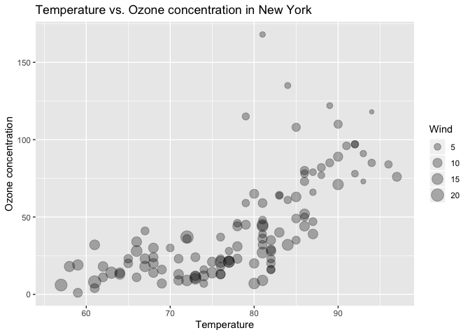

```r
airquality %>%
  ggplot(aes(Temp, Ozone)) +
    geom_point(aes(size = Wind), alpha = 0.3) +
    xlab("Temperature") +
    ylab("Ozone concentration") +
    ggtitle("Temperature vs. Ozone concentration in New York")
```

Another plot:

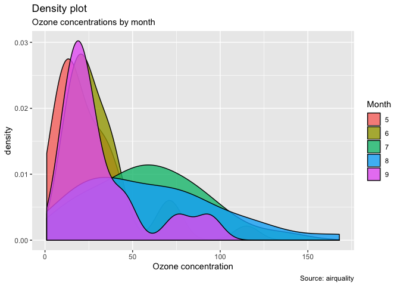

```r
airquality %>%
  ggplot(aes(Ozone)) +
  geom_density(aes(fill=factor(Month)),alpha=0.8)+
  labs(title="Density plot",
       subtitle="Ozone concentrations by month",
       caption="Source: airquality",
       x="Ozone concentration",
       fill="Month")
```

## Recycling

For people who want to take things further.

Evaluate this code and describe the result. Presumably the analyst’s intent was to get the data for Rwanda and Afghanistan. Did they succeed? Why or why not? If not, what is the correct way to do this?

```r
DT::datatable(filter(gapminder, country == c("Rwanda", "Afghanistan")))
```

|  | country | continent | year | lifeExp | pop | gdpPercap |
| --- | --- | --- | --- | --- | --- | --- |
| 1 | Afghanistan | Asia | 1957 | 30.332 | 9240934 | 820.8530296 |
| 2 | Afghanistan | Asia | 1967 | 34.02 | 11537966 | 836.1971382 |
| 3 | Afghanistan | Asia | 1977 | 38.438 | 14880372 | 786.11336 |
| 4 | Afghanistan | Asia | 1987 | 40.822 | 13867957 | 852.3959448 |
| 5 | Afghanistan | Asia | 1997 | 41.763 | 22227415 | 635.341351 |
| 6 | Afghanistan | Asia | 2007 | 43.828 | 31889923 | 974.5803384 |
| 7 | Rwanda | Africa | 1952 | 40 | 2534927 | 493.3238752 |
| 8 | Rwanda | Africa | 1962 | 43 | 3051242 | 597.4730727 |
| 9 | Rwanda | Africa | 1972 | 44.6 | 3992121 | 590.5806638 |
| 10 | Rwanda | Africa | 1982 | 46.218 | 5507565 | 881.5706467 |

[output cut: 2 more lines]